# Exercício 3

Henrique Capatto RA 146406

# Geração de números aleatórios

Execução do Terceiro exercício proposto

## Método da Rejeição

O exercício em questão porpõe gerar números aleatórios que sigam a função densidade da distribuição normal $\eta \sim (\mu ,\sigma ^{2})$:

$$f_{X}(x) = \frac{1} {\sqrt{2\pi \sigma ^{2}}} e^{-(\frac{1}{2})(\frac{(x-\mu)^{2}}{\sigma^{2}})}, \forall x\in (-\infty ,\infty ), \forall \sigma\in (0,\infty )$$

Para gerar números aleatórios utilizando o **método da rejeição**, precisamos:

1. Encontrar uma variável aleatória $Y$ com densidade $g$,tal que;
   $$\frac{f(t)}{g(t)}\leq c, \forall t: f(t) > 0$$
2. Para cada variável aleatória a ser gerada;
1. Simule uma amostra $y$ a partir de $g$:
2. Simule $u$ com distribuição uniforme(0,1)
3. Se $u<\frac{f(y)}{c*g(y)}$, então retorne $x=y$.Caso contrário, retorne ao Passo $2a$

```r
#modulo de x menos x ao quadrado dividido por 2 é menor ou igual a 1/2

#faremos a geração pra normal 0, 1 depois aplicamos a transformaão pra
#função que queremos

rnorm2= function(n,mu,sigma){

  c=sqrt(2*exp(1)/pi)

  i=0

  Y <- numeric(n)

  #contr=0

  while(i < n){

    unif01=runif(1)

    unif02=runif(1)

    unif03=runif(1)

    x=-log(unif01)

    if(unif02  < exp((-(x-1)^2)/2) ){

      i <- i + 1

      if(unif03 <= 0.5){
        x=-x
      }

      Y[i]=mu+(x*sigma2)
    }

    }


  return (Y)
}


n <- 1e4

mu <- 2

sigma2 <- 4

amostra=rnorm2(n,mu,sigma2)
```

A seguir, gráfico gerado, um histograma especificamente, a partir a amostra de tamanho 10^{4},sobreposto ao gráfico da função referida anteriormente.

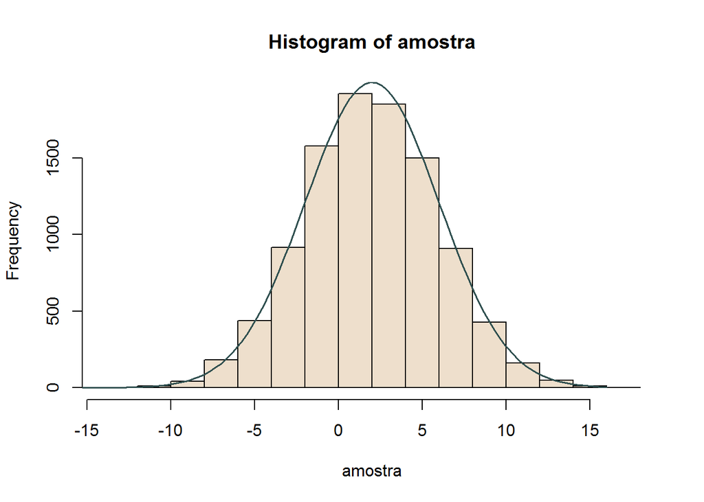

```r
hist(amostra,col="antiquewhite2",border="black")
curve(2*n*dnorm(x,mu,sigma2),xlim=c(-4*sigma2,4*sigma2),
lw=1.5,col="darkslategray",add=TRUE)
```

O teste que se utilizará para validar a hipótese será o Chi-Quadrado de Aderência, possuinte do objetivo de testar a adeuqabilidade de um modelo probabilistico em relação a um conjunto de dados observados. Faremos o teste utilizando os quartis téoricos e os orginários da amostra aleatória. A hipótese nula é a de que a amostra segue a distribuição deseja. A alternativa, é a de que não segue.

Definição de $\alpha=$ 0.05

OS quartis teóricos desta distribuição são determinados pela pontos em que a função acumulada atinge os valores pré-especificada dos quantis(0.25,0.5,0.75).

```r
quartis = c(q1,q2,q3)

resTmp = cut(amostra, quartis, include.lowest=TRUE)

obs = as.integer(table(resTmp))

esp = rep(n/4, 4)

p_valor <- chisq.test(cbind(obs, esp))[3]

prop.table(table(resTmp))
```

O p-valor resultante é: 0.2987369

Logo, se p-valor for $<0.05$, rejeitar-se-á a hipótese nula. Caso contrário, não se preterirá.